# Luigi’s COVID-19 Analyses

Created: 9/6/2023  
Last update: 02/20/2024

Analysis datasets and copy of the Rmd are in Rutgers box:  
https://rutgers.app.box.com/folder/227391194192

GitHub Repo:  
https://github.com/sargdavid/luigi_covid19

# Setup

```r
options(scipen = 999)

# install.packages("zlibbioc_1.48.0.tar.gz",
#                  repos = NULL,
#                  type = "source")

# if (!require("BiocManager",
#              quietly = TRUE))
# BiocManager::install("MOFA2")

# if (!require("BiocManager",
#              quietly = TRUE))
# install.packages("BiocManager")
# BiocManager::install("ReactomePA")
# BiocManager::install("org.Hs.eg.db")

require(data.table)
require(ggplot2)
require(table1)
require(DESeq2)
require(ReactomePA)
```

[output not shown]

```r
require(org.Hs.eg.db)
# require(zlibbioc)
# require(MOFA2)
require(psych)

require(tidyverse)
require(tidytlg)
require(gridExtra)
require(nnet)

# Not Used:
# require(NBZIMM)::lme.zig(fixed = logTPM ~ ibd_infl,
#                          random = ~ 1| Batch,
#                          zi_fixed = ~ ibd_infl,
#                          data = dt,
#                          verbose = FALSE)
# BiocManager::install("clusterProfiler")
# require(clusterProfiler)
# require(gt)
# require(rtables)
```

**Meeting 3/14/2024:**  
1. Lu: cytokine storm can more likely happen to the ICU/sever patients. Therefore, stratify by severity etc.  
2. My ELISA set is still missing ACE2 and DPP4. I need to check the data to see why these columns got deleted.  
3. The 21 proteins included in the attached were measured in pg/mL but the missing ones in ug/mL  
4. Twopartm::AME did not converge with the bootstrap option for the 95%CI. Therefore, I used the delta method. Need to check the convergence issue tomorrow with Javier and Yajie.

*ToDos:*  
1. Transform the data using quantile or Fisher-Yates normalization (DNAMR::cnormalize), and perform factor analysis (psych::fa instead of factanal)  
2. Apply tow-part model to normalized gene expressions.  
3. Reactom Pathway Analysis (ReactomPA) repeated on these sets of genes  
4. Factor analysis of gene expressions. Compare the factors with Gene Ontology, Reactom Pathways, KEGG pathways etc. Include Module Analysis (see WGCNA: Weighted Correlation Network Analysis by Steve Horvath. We used it in lncRNA paper. Can be more applicable for Paper 2 on lncRNAs.)

**Feedbakc from stats AI meeting 3/8/2024:**  
1. Use MOFA (Bernard)  
2. Check Diabolo and COMBI packages  
3. Causal representative learning and causal graphs/networks for coding/non-coding RNA interactions (Mingshi)  
4. Color modules (Caesar, Stefan & John)  
5. Factor analysis  
6. Gene ontology to connect factors to GOs (Javier) 7. Ask Lu if I can share Table 1 with Michael Katehakis

**Meeting 2/1/2024:**  
1. RNA vs. ELISA - need to know coding genes  
2. Neanderthal genes  
3. List of genes from Lu  
4. IFI27: what cyto/ cemokine is associated with it (from ELISA panel)? Cytokines should regulate IFI27  
5. BAMBI vs ACE2 (new ELISA)  
6. Find specific proteins (ELISA) that result in the expression of another gene  
7. Pathway analysis with ReactomPA (DONE)  
8. Focus on DM  
9. Factor analysis  
10. Anti-IL6 was used in pandemic. Look at INFg, IL1, IL6 and TNFa

**Javier, 9/15/2023:**  
1. Build survival model using LOS as dates. Assuming all death are in-hospital, end of LOS.

**Meeting 9/19/23:**  
1. Was everybody admitted with COVID-19 symptoms? In Marshall’s email from 11/14/23 8:01AM he said “not sure [admission DX] will be necessary since admitting DX will be COVID”. Does this mean that controls where also admitted with COVID diagnoses? How?  
2. Do survival for in-patients only using LOS.  
3. Look at LOS of dead patients.  
4. Do DM patients have higher WHO OSCI score at admission?  
5. COVID+DM = more likely to go to ICU vs COVID+noDM? 6. Outcomes: death, LOS, ventilation, ICU.

**Meeting 9/7/23:**  
1. Look at inflammation signature w/wo DM, stratified by COVID.  
2. in COVID, coagulation cascade pathway was affected. See if we can find it in clin. data, ELIZA or RNA-seq. Should coagulation be considered in COVID patients’ treatment?  
3. Coding/non-coding gene co-expression.  
4. Activation of inflammatory pathways because we have transcriptome, not just genome.  
5. Neanderthals’ genes (see Lu’s email).  
6. Important factors: Critical care, WHO OSCI, LOS, ACE inhibitors, age>55, HTN, DM.

```r
# rows_empty <- function(mat) {
#   unlist(apply(mat, 1, function(x) !any(nzchar(x))), simplify = FALSE)
# }
#
# #' Emit a table as RTF via gentlg
# #' @inheritParams formatters::matrix_form
# tt_to_tbldf <- function(tt) {
#   mpf <- matrix_form(tt, indent_rownames = FALSE, expand_newlines = FALSE)
#   strmat <- mf_strings(mpf)
#   nhl <- mf_nlheader(mpf)
#   strbody <- strmat[-(1:nhl), , drop = FALSE]
#   row_type <- apply(strbody, 1,
#                     function(x) {
#                       nonempty <- nzchar(x)
#                       if(all(!nonempty)) { ## shouldn't ever happen
#                         "EMPTY"
#                       } else if (nonempty[1] && all(!nonempty[-1])) {# only 1st cell nonempty
#                         "HEADER"
#                       } else {
#                         if(x[1] == "N")
#                           "N"
#                         else
#                           "VALUE"
#                       }
#                     })
#   rowdf <- mf_rinfo(mpf)
#   rinds <- mf_lgrouping(mpf)[-(1:nhl)] - mf_nrheader(mpf)
#   indentme <- rowdf$indent[rinds]
#   anbr <- cumsum(!is.na(c(0, head(rowdf$trailing_sep, -1))))[rinds] + 1 ## so it starts at 1
#   roworder <- 1:NROW(rowdf) - (anbr - 1)
#   newrows <- c(0, ifelse(tail(anbr, -1) == head(anbr, -1), 0, 1))
#
#   tbldf <- as.data.frame(strbody)
#   names(tbldf) <- c("label", paste("col", seq(1, ncol(tbldf) - 1)))
#   cbind(tbldf, data.frame(row_type = row_type,
#                           anbr = anbr,
#                           indentme = indentme,
#                           roworder = roworder,
#                           newrows = newrows,
#                           stringsAsFactors = FALSE))
# }
#
# #' @rdname tt_to_tbldf
# #' @param file character(1). File path for output.
# tt_to_tlgrtf <- function(tt, file = "./table") {
#   df <- tt_to_tbldf(tt)
#   mpf <- matrix_form(tt, indent_rownames = FALSE, expand_newlines = FALSE)
#
#   strmat <- mf_strings(mpf)
#   nhl <- mf_nlheader(mpf)
#   nspancols <- nhl - 1L
#   if(nspancols > 0)
#     csph <- lapply(seq_len(nspancols), function(ii) strmat[ii,])
#   else
#     csph <- NULL
#   gentlg(df,
#          colspan = csph,
#          file = file,
#          colheader = strmat[nhl,],
#          title = main_title(tt),
#          footers = c(main_footer(tt), prov_footer(tt)))
# }
```

# Load data

NOTE: these datasets were created from source in ‘luigi_covid19_data_preprocessing_02202024.Rmd’

```r
load("../Data/dt1.RData")
load("../Data/dt_rna.RData")
load("../Data/rnaseq_meta.RData")
load("../Data/rfa.RData")
```

# Clinical Data

## Table 1

```r
t1 <- table1( ~.| `Study Group` + AnyDM,
              data = dt1[, -c("Real ID",
                              "Reason_for_Admission",
                              "Adm_DX2",
                              "Admit Date",
                              "Discharge Date")])

t1
```

|  | No COVID 0 (N=39) | No COVID 1 (N=33) | COVID 0 (N=76) | COVID 1 (N=34) | Overall 0 (N=115) | Overall 1 (N=67) |
| --- | --- | --- | --- | --- | --- | --- |
| Whole Blood |  |  |  |  |  |  |
| Whole Blood | 0 (0%) | 0 (0%) | 41 (53.9%) | 21 (61.8%) | 41 (35.7%) | 21 (31.3%) |
| Whole Blood + Trizol | 0 (0%) | 0 (0%) | 35 (46.1%) | 13 (38.2%) | 35 (30.4%) | 13 (19.4%) |
| Missing | 39 (100%) | 33 (100%) | 0 (0%) | 0 (0%) | 39 (33.9%) | 33 (49.3%) |
| Plasma |  |  |  |  |  |  |
| 0 | 18 (46.2%) | 13 (39.4%) | 40 (52.6%) | 13 (38.2%) | 58 (50.4%) | 26 (38.8%) |
| 1 | 21 (53.8%) | 20 (60.6%) | 36 (47.4%) | 21 (61.8%) | 57 (49.6%) | 41 (61.2%) |
| Inpatient=1, ER=2, OP=3 |  |  |  |  |  |  |
| Inpatient | 34 (87.2%) | 30 (90.9%) | 69 (90.8%) | 31 (91.2%) | 103 (89.6%) | 61 (91.0%) |
| ER | 4 (10.3%) | 2 (6.1%) | 5 (6.6%) | 2 (5.9%) | 9 (7.8%) | 4 (6.0%) |
| OP | 1 (2.6%) | 1 (3.0%) | 2 (2.6%) | 1 (2.9%) | 3 (2.6%) | 2 (3.0%) |
| 30 Day Readmission |  |  |  |  |  |  |
| Mean (SD) | 0.231 (0.427) | 0.242 (0.435) | NA (NA) | NA (NA) | 0.231 (0.427) | 0.242 (0.435) |
| Median [Min, Max] | 0 [0, 1.00] | 0 [0, 1.00] | NA [NA, NA] | NA [NA, NA] | 0 [0, 1.00] | 0 [0, 1.00] |
| Missing | 0 (0%) | 0 (0%) | 76 (100%) | 34 (100%) | 76 (66.1%) | 34 (50.7%) |
| 90 Day Readmission |  |  |  |  |  |  |
| Mean (SD) | 0.359 (0.486) | 0.364 (0.489) | NA (NA) | NA (NA) | 0.359 (0.486) | 0.364 (0.489) |
| Median [Min, Max] | 0 [0, 1.00] | 0 [0, 1.00] | NA [NA, NA] | NA [NA, NA] | 0 [0, 1.00] | 0 [0, 1.00] |
| Missing | 0 (0%) | 0 (0%) | 76 (100%) | 34 (100%) | 76 (66.1%) | 34 (50.7%) |
| 30 Day Mortality |  |  |  |  |  |  |
| Mean (SD) | 0.103 (0.307) | 0.0303 (0.174) | NA (NA) | NA (NA) | 0.103 (0.307) | 0.0303 (0.174) |
| Median [Min, Max] | 0 [0, 1.00] | 0 [0, 1.00] | NA [NA, NA] | NA [NA, NA] | 0 [0, 1.00] | 0 [0, 1.00] |
| Missing | 0 (0%) | 0 (0%) | 76 (100%) | 34 (100%) | 76 (66.1%) | 34 (50.7%) |
| 90 Day Mortality |  |  |  |  |  |  |
| Mean (SD) | 0.103 (0.307) | 0.0303 (0.174) | NA (NA) | NA (NA) | 0.103 (0.307) | 0.0303 (0.174) |
| Median [Min, Max] | 0 [0, 1.00] | 0 [0, 1.00] | NA [NA, NA] | NA [NA, NA] | 0 [0, 1.00] | 0 [0, 1.00] |
| Missing | 0 (0%) | 0 (0%) | 76 (100%) | 34 (100%) | 76 (66.1%) | 34 (50.7%) |
| Age |  |  |  |  |  |  |
| Mean (SD) | 67.5 (18.1) | 64.2 (16.8) | 61.4 (16.4) | 67.0 (13.7) | 63.5 (17.2) | 65.6 (15.2) |
| Median [Min, Max] | 74.0 [22.0, 92.0] | 66.0 [28.0, 94.0] | 61.5 [21.0, 93.0] | 68.5 [36.0, 89.0] | 64.0 [21.0, 93.0] | 68.0 [28.0, 94.0] |

[output cut: 408 more lines]

```r
write.table (t1 ,
             file = "../tmp/table1.csv",
             col.names = TRUE,
             row.names = FALSE,
             # append = TRUE,
             sep = ',')
```

## DX1 Analysis

```r
length(unique(rfa$Level1))
```

```
[1] 16
```

```r
level1_n <- rfa[, .(N_Level1 = .N),
                by = list(`Study Group`,
                          Level1)]
level1_n <- dcast.data.table(data = level1_n,
                             Level1 ~ `Study Group`)
level1_n
```

| Level1 | COVID | No COVID |
| --- | --- | --- |
| NA | NA | 1 |
|  | NA | 1 |
| Certain infectious and parasitic diseases | 1 | 1 |
| Codes for special purposes | 77 | NA |
| Diseases of the blood and blood-forming organs and certain disorders involving the immune mechanism | NA | 2 |
| Diseases of the circulatory system | NA | 9 |
| Diseases of the digestive system | 2 | 4 |
| Diseases of the genitourinary system | NA | 7 |
| Diseases of the musculoskeletal system and connective tissue | NA | 2 |
| Diseases of the nervous system | NA | 1 |

[output cut: 6 more lines]

### In-hospital death DX1

```r
tmp1 <- rfa[Expired == 1,
           c("Real ID",
             "Study Group",
             "Reason_for_Admission",
             "Age",
             "Race",
             "Level1",
             "Level2",
             "Level3",
             "Level4",
             "Level5",
             "Level6",
             "Level7")]
```

### 90-Day after discharge death DX1

```r
tmp2 <- rfa[rfa$`90 Day Mortality` == 1,
           c("Real ID",
             "Study Group",
             "Reason_for_Admission",
             "Age",
             "Race",
             "Level1",
             "Level2",
             "Level3",
             "Level4",
             "Level5",
             "Level6",
             "Level7")]
```

### 90-Day after discharge readmission DX1

```r
tmp3 <- rfa[rfa$`90 Day Readmission`== 1,
           c("Real ID",
             "Study Group",
             "Reason_for_Admission",
             "Age",
             "Race",
             "Level1",
             "Level2",
             "Level3",
             "Level4",
             "Level5",
             "Level6",
             "Level7")]
```

```r
length(unique(rfa$Level2))
```

```
[1] 37
```

```r
level2_n <- rfa[, .(N_Level2 = .N),
                by = list(`Study Group`,
                          Level1,
                          Level2)]

level2_n <- dcast.data.table(data = level2_n,
                             Level1 + Level2 ~ `Study Group`)
level2_n
```

| Level1 | Level2 | COVID | No COVID |
| --- | --- | --- | --- |
| NA | NA | NA | 1 |
|  |  | NA | 1 |
| Certain infectious and parasitic diseases | Other bacterial diseases | 1 | 1 |
| Codes for special purposes | Provisional assignment of new diseases of uncertain etiology or emergency use | 77 | NA |
| Diseases of the blood and blood-forming organs and certain disorders involving the immune mechanism | Aplastic and other anemias and other bone marrow failure syndromes | NA | 1 |
| Diseases of the blood and blood-forming organs and certain disorders involving the immune mechanism | Nutritional anemias | NA | 1 |
| Diseases of the circulatory system | Cerebrovascular diseases | NA | 2 |
| Diseases of the circulatory system | Hypertensive diseases | NA | 1 |
| Diseases of the circulatory system | Ischemic heart diseases | NA | 2 |
| Diseases of the circulatory system | Other forms of heart disease | NA | 4 |

[output cut: 27 more lines]

## Death

### Death vs. COVID

```r
addmargins(table(Death = dt1$Expired,
                 COVID = dt1$`Study Group`))
```

```
     COVID
Death No COVID COVID Sum
  No        69    98 167
  Yes        3    12  15
  Sum       72   110 182
```

```r
m1 <- glm(Expired ~ `Study Group`,
          family = binomial,
          data = dt1)
s1 <- summary(m1)
ci1 <- confint(m1)
out1 <- data.table(Response = "Dead",
                   Comparison = "COVID vs. No Covid",
                   OR = round(exp(s1$coefficients[-1, 1]),
                              2),
                   `95% C.I.L.B.` = exp(ci1[2, 1]),
                   `95% C.I.U.B.` = exp(ci1[2, 2]),
                   `p-Value` = ifelse(s1$coefficients[-1, 4] >= 0.001,
                                      round(s1$coefficients[-1, 4],
                                            3),
                                      "<0.001"),
                   sign = ifelse(s1$coefficients[-1, 4] <= 0.05,
                                 ifelse(s1$coefficients[-1, 4] <= 0.01,
                                        "**",
                                        "*"), ""))

out1
```

| Response | Comparison | OR | 95% C.I.L.B. | 95% C.I.U.B. | p-Value | sign |
| --- | --- | --- | --- | --- | --- | --- |
| Dead | COVID vs. No Covid | 2.82 | 0.8563815 | 12.69747 | 0.119 |  |

### Death vs DM, COVID only

```r
covid <- droplevels(dt1[`Study Group` == "COVID", ])

chisq.test(covid$Expired,
           covid$AnyDM)
```

```
    Pearson's Chi-squared test with Yates' continuity correction

data:  covid$Expired and covid$AnyDM
X-squared = 1.4048, df = 1, p-value = 0.2359
```

```r
addmargins(table(Death = covid$Expired,
                 AnyDM = covid$AnyDM))
```

```
     AnyDM
Death   0   1 Sum
  No   70  28  98
  Yes   6   6  12
  Sum  76  34 110
```

```r
nocovid <- droplevels(dt1[`Study Group` != "COVID", ])
```

### Death vs Obese, COVID only

```r
chisq.test(covid$Expired,
           covid$Obese)

addmargins(table(Death = covid$Expired,
                 Obese = covid$Obese))
```

### Death vs BMI, COVID only

```r
t.test(covid$BMI ~ covid$Expired)

ggplot(covid,
       aes(x = Expired,
           y = BMI)) +
  geom_boxplot(outlier.shape = "") +
  geom_point(aes(group = `Real ID`),
             shape = 21,
             size = 2,
             position = position_dodge(0.3)) +
  ggtitle("COVID Patients Only") +
  theme_bw()
```

### Death vs Critical Care

Significant

```r
addmargins(table(Death = covid$Expired,
                 CrCare = covid$`Critical Care`))

chisq.test(covid$Expired,
           covid$`Critical Care`)

m3 <- glm(Expired ~ `Critical Care`,
          family = binomial,
          data = covid)
s3 <- summary(m3)

out3 <- data.table(Response = "Dead",
                   Comparison = c("ICU: Yes vs. No"),
                   OR = round(exp(s3$coefficients[-1, 1]),
                              2),
                   `95% C.I.L.B.` = exp(s3$coefficients[-1, 1] - 1.96*s3$coefficients[-1, 2]),
                   `95% C.I.U.B.` = exp(s3$coefficients[-1, 1] + 1.96*s3$coefficients[-1, 2]),
                   `p-Value` = ifelse(s3$coefficients[-1, 4] >= 0.001,
                                      round(s3$coefficients[-1, 4], 3),
                                      "<0.001"),
                   sign = ifelse(s3$coefficients[-1, 4] <= 0.05,
                                 ifelse(s3$coefficients[-1, 4] <= 0.01,
                                        "**",
                                        "*"), ""))

out3

m3 <- glm(Expired ~ `Critical Care`,
          family = binomial,
          data = nocovid)
s3 <- summary(m3)

out31 <- data.table(Response = "Dead",
                    Comparison = c("ICU: Yes vs. No"),
                    OR = round(exp(s3$coefficients[-1, 1]),
                               2),
                    `95% C.I.L.B.` = exp(s3$coefficients[-1, 1] - 1.96*s3$coefficients[-1, 2]),
                    `95% C.I.U.B.` = exp(s3$coefficients[-1, 1] + 1.96*s3$coefficients[-1, 2]),
                    `p-Value` = ifelse(s3$coefficients[-1, 4] >= 0.001,
                                       round(s3$coefficients[-1, 4], 3),
                                       "<0.001"),
                    sign = ifelse(s3$coefficients[-1, 4] <= 0.05,
                                  ifelse(s3$coefficients[-1, 4] <= 0.01,
                                         "**",
                                         "*"), ""))

out31
```

### Death vs. COVID | Diabetes

No significant difference.  
Model with interaction is worse.

```r
m2 <- glm(Expired ~ `Study Group` +
            AnyDM,
          family = binomial,
          data = dt1)
s2 <- summary(m2)

out2 <- data.table(Response = "Dead",
                   Comparison = c("COVID vs. No Covid",
                                  "Any DM vs. No DM"),
                   OR = round(exp(s2$coefficients[-1, 1]),
                              2),
                   `95% C.I.L.B.` = exp(s2$coefficients[-1, 1] - 1.96*s2$coefficients[-1, 2]),
                   `95% C.I.U.B.` = exp(s2$coefficients[-1, 1] + 1.96*s2$coefficients[-1, 2]),
                   `p-Value` = ifelse(s2$coefficients[-1, 4] >= 0.001,
                                      round(s2$coefficients[-1, 4], 3),
                                      "<0.001"),
                   sign = ifelse(s2$coefficients[-1, 4] <= 0.05,
                                 ifelse(s2$coefficients[-1, 4] <= 0.01,
                                        "**",
                                        "*"), ""))

out2
```

### Death vs COVID, adjusted for critical care

Both significant in additive model.

```r
m4 <- glm(Expired ~ `Study Group` + `Critical Care`,
          family = binomial,
          data = dt1)
s4 <- summary(m4)
ci4 <- confint(m4)

out4 <- data.table(Response = "Dead",
                   Comparison = c("COVID vs. No Covid",
                                  "ICU"),
                   OR = round(exp(s4$coefficients[-1, 1]),
                              2),
                   `95% C.I.L.B.` = exp(ci4[-1, 1]),
                   `95% C.I.U.B.` = exp(ci4[-1, 2]),
                   `p-Value` = ifelse(s4$coefficients[-1, 4] >= 0.001,
                                      round(s4$coefficients[-1, 4],
                                            3),
                                      "<0.001"),
                   sign = ifelse(s4$coefficients[-1, 4] <= 0.05,
                                 ifelse(s4$coefficients[-1, 4] <= 0.01,
                                        "**",
                                        "*"), ""))

out4
```

No significance in interaction model.

```r
m41 <- glm(Expired ~ `Study Group`*`Critical Care`,
           family = binomial,
           data = dt1)
summary(m41)
```

### Death vs COVID, adjusted for DM

No significance

```r
m5 <- glm(Expired ~ `Study Group` +
            AnyDM,
          family = binomial,
          data = dt1)
summary(m5)
```

### Death vs COVID, adjusted

```r
m6 <- glm(Expired ~ `Study Group` +
            AnyDM +
            Age_Category +
            Sex +
            Race +
            BMI,
          family = binomial,
          data = dt1)
summary(m6)
```

### New variable: DM+Obesity

```r
chisq.test(dt1$AnyDM,
           dt1$Obese)
```

## ICU

### ICU LOS

```r
summary(dt1$`ICU LOS`)
hist(dt1$`ICU LOS`, 200)
hist(log2(dt1$`ICU LOS` + 1), 200)

m7 <- lm(log2(`ICU LOS` + 1) ~ AnyDM +
           Age +
           Sex +
           Race +
           BMI +
           `Critical Care`,
         family = binomial,
         data = dt1)
summary(m7)
```

### Critical care

```r
m8 <- glm(`Critical Care` ~ AnyDM +
            Age +
            Sex +
            Race +
            BMI,
          family = binomial,
          data = droplevels(dt1))
summary(m8)
```

## WHO-OSCI

### Desease severity at baseline by WHO-OSCI

if <5 = mild  
if >= 5 = severe  
5 = very sick  
6 = intubated  
7 = ventilated  
if 8: dead

```r
covid$who_osci_d1_cat <- "Dead"
covid$who_osci_d1_cat[as.numeric(as.character(covid$`WHO-OSCI D1`)) < 8] <- "Severe"
covid$who_osci_d1_cat[as.numeric(as.character(covid$`WHO-OSCI D1`)) < 5] <- "Mild"

covid$who_osci_d1_cat <- factor(covid$who_osci_d1_cat,
                                levels = c("Mild",
                                           "Severe"))
summary(covid$who_osci_d1_cat)
```

```r
addmargins(table("WHO-OSCI D1" = dt1$`WHO-OSCI D1`,
                 CC = dt1$`Critical Care`))
```

### WHO-OSCI over time

```r
tmp <- dt1[, c("Real ID",
               "Study Group",
               "AnyDM",
               "Expired",
               "WHO-OSCI D1",
               "WHO-OSCI D3",
               "WHO-OSCI D7",
               "WHO-OSCI D14",
               "WHO-OSCI D21",
               "WHO-OSCI D28",
               "WHO-OSCI DISCHARGE")]

tmp <- melt.data.table(tmp,
                       id.vars = c(1:4),
                       variable.name = "Day",
                       value.name = "WHO_OSCI")
tmp$Day <- factor(tmp$Day,
                  levels = unique(tmp$Day))

tmp <- tmp[!is.na(tmp$WHO_OSCI), ]
ggplot(tmp,
       aes(x = Day,
           y = WHO_OSCI,
           group = `Real ID`,
           color = `Real ID`)) +
  facet_wrap(~ AnyDM) +
  geom_line(position = position_dodge(0.3)) +
  theme_bw() +
  theme(legend.position = "none") +
  theme(axis.text.x = element_text(angle = 45,
                                   hjust = 1))
```

```r
table(dt1$`WHO-OSCI D1`,
      dt1$Expired)
```

### Table 2

```r
t2 <- dcast.data.table(`Real ID` ~ Day,
                       value.var = "WHO_OSCI",
                       data = tmp[Expired == "Yes", ])

write.csv(t2,
          file = "tmp/table2.csv",
          row.names = FALSE)

t2
```

```r
dt1[,
    .(N = .N,
      mu_los = mean(LOS),
      sem_los = sd(LOS)/sqrt(.N)),
    by = c("Study Group")]

dt1[,
    .(N = .N,
      mu_los = mean(LOS),
      sem_los = sd(LOS)/sqrt(.N)),
    by = c("Expired")]

dt1[,
    .(N = .N,
      mu_los = mean(LOS),
      sem_los = sd(LOS)/sqrt(.N)),
    by = c("Expired",
           "Study Group")]

dt1[LOS > 1,
    .(N = .N,
      mu_los = mean(LOS),
      sem_los = sd(LOS)/sqrt(.N)),
    by = c("Expired",
           "Study Group")]
```

```r
dt1$LOS[dt1$`Real ID` == 771982]
```

# ELISA

```r
dt_elisa <- data.table(dt1[, c("Real ID",
                               "Study Group",
                               "AnyDM")],
                       dt1[, `G-CSF (CSF-3)`:`TNF beta`])

# Remove patients with no ELISA data
dt_elisa <- dt_elisa[!is.na(`G-CSF (CSF-3)`), ]

addmargins(table(COVID = dt_elisa$`Study Group`,
      AnyDM = dt_elisa$AnyDM))
```

```
          AnyDM
COVID        0   1 Sum
  No COVID  38  30  68
  COVID     35  19  54
  Sum       73  49 122
```

```r
summary(dt_elisa)
```

```
   Real ID            Study Group AnyDM  G-CSF (CSF-3)         GM-CSF         IFN alpha
 Length:122         No COVID:68   0:73   Min.   : 0.0000   Min.   : 0.000   Min.   : 0.0000
 Class :character   COVID   :54   1:49   1st Qu.: 0.1525   1st Qu.: 0.000   1st Qu.: 0.0000
 Mode  :character                        Median : 1.0350   Median : 0.000   Median : 0.0000
                                         Mean   : 1.7691   Mean   : 2.587   Mean   : 0.4440
                                         3rd Qu.: 2.0700   3rd Qu.: 0.000   3rd Qu.: 0.1988
                                         Max.   :11.5550   Max.   :77.140   Max.   :11.6700
   IFN gamma         IL-1 beta           IL-2             IL-4             IL-5
 Min.   : 0.0000   Min.   :0.0000   Min.   : 0.000   Min.   : 0.000   Min.   : 0.000
 1st Qu.: 0.8225   1st Qu.:0.0000   1st Qu.: 0.000   1st Qu.: 2.849   1st Qu.: 0.000
 Median : 1.5425   Median :0.4300   Median : 0.000   Median : 6.750   Median : 0.460
 Mean   : 2.3860   Mean   :0.8935   Mean   : 1.934   Mean   : 9.987   Mean   : 1.460
 3rd Qu.: 2.8225   3rd Qu.:1.0987   3rd Qu.: 0.725   3rd Qu.:13.385   3rd Qu.: 1.604
 Max.   :14.4400   Max.   :7.6600   Max.   :35.050   Max.   :54.190   Max.   :18.125
      IL-6           IL-8 (CXCL8)         IL-10           IL-12p70          IL-13
 Min.   :   0.000   Min.   : 0.0000   Min.   : 0.000   Min.   : 0.000   Min.   : 0.000
 1st Qu.:   0.000   1st Qu.: 0.3475   1st Qu.: 0.000   1st Qu.: 0.000   1st Qu.: 0.000
 Median :   3.208   Median : 1.0325   Median : 0.000   Median : 0.585   Median : 0.000
 Mean   :  19.687   Mean   : 2.5558   Mean   : 0.641   Mean   : 1.405   Mean   : 2.203
 3rd Qu.:  14.030   3rd Qu.: 2.6412   3rd Qu.: 0.510   3rd Qu.: 1.640   3rd Qu.: 1.051
 Max.   :1074.725   Max.   :45.8400   Max.   :21.980   Max.   :17.465   Max.   :48.925
 IL-17A (CTLA-8)       IL-18        IP-10 (CXCL10)     MCP-1 (CCL2)    MIP-1 alpha (CCL3)
 Min.   : 0.0000   Min.   :  0.00   Min.   :  0.000   Min.   :  0.00   Min.   : 0.0000
 1st Qu.: 0.0000   1st Qu.: 33.98   1st Qu.:  8.182   1st Qu.: 13.38   1st Qu.: 0.0000
 Median : 0.3500   Median : 52.98   Median : 14.620   Median : 24.58   Median : 0.0375
 Mean   : 0.9194   Mean   : 82.30   Mean   : 21.732   Mean   : 35.61   Mean   : 0.9178
 3rd Qu.: 1.0350   3rd Qu.: 79.38   3rd Qu.: 27.901   3rd Qu.: 49.71   3rd Qu.: 0.7538
 Max.   :17.2550   Max.   :618.62   Max.   :113.880   Max.   :199.57   Max.   :11.1500
 MIP-1 beta (CCL4)   TNF alpha        TNF beta
 Min.   : 0.000    Min.   :0.000   Min.   : 0.00000
 1st Qu.: 0.000    1st Qu.:0.590   1st Qu.: 0.00000
 Median : 3.833    Median :0.945   Median : 0.00000
 Mean   :12.228    Mean   :1.385   Mean   : 0.54102
 3rd Qu.:14.795    3rd Qu.:1.731   3rd Qu.: 0.04375
 Max.   :70.140    Max.   :9.005   Max.   :10.00500
```

## ELISA long format

```r
dt_elisa_l <- melt.data.table(data = dt_elisa,
                              id.vars = 1:3,
                              measure.vars = 4:ncol(dt_elisa),
                              variable.name = "Protein",
                              value.name = "Concentration[pg/mL]")

dt_elisa_l[, grp := factor(paste(`Study Group`,
                                 AnyDM,
                                 sep = "_"),
                           levels = c("No COVID_0",
                                      "COVID_0",
                                      "No COVID_1",
                                      "COVID_1"),
                           labels = c("No COVID/No DM",
                                      "COVID/No DM",
                                      "No COVID/DM",
                                      "COVID/DM"))]

dt_elisa_l$Log10Conc <- log10(dt_elisa_l$`Concentration[pg/mL]` + 1)
```

### Histograms

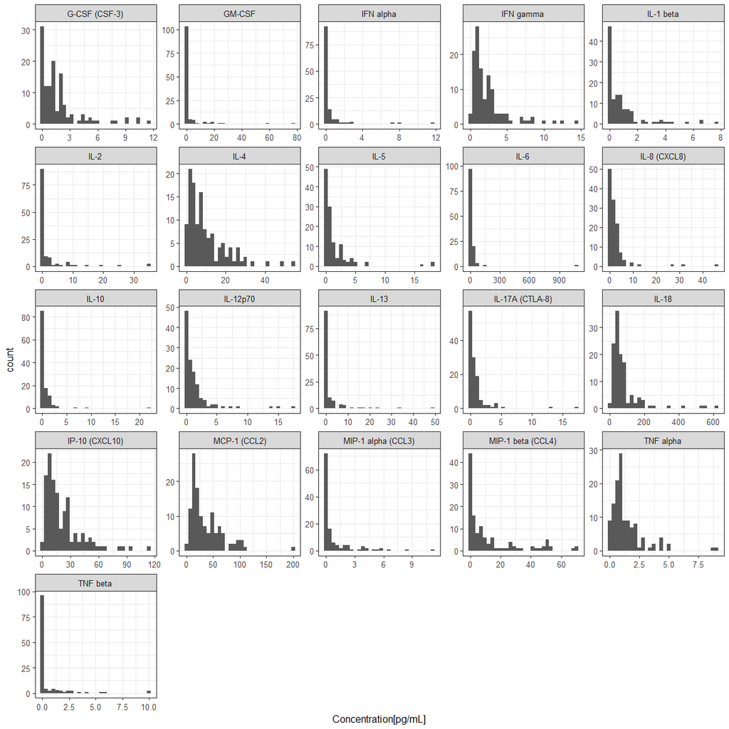

```r
ggplot(dt_elisa_l,
       aes(x = `Concentration[pg/mL]`)) +
  facet_wrap(~ Protein,
             scale = "free") +
  geom_histogram(bins = 30) +
  theme_bw()
```

### Boxplot

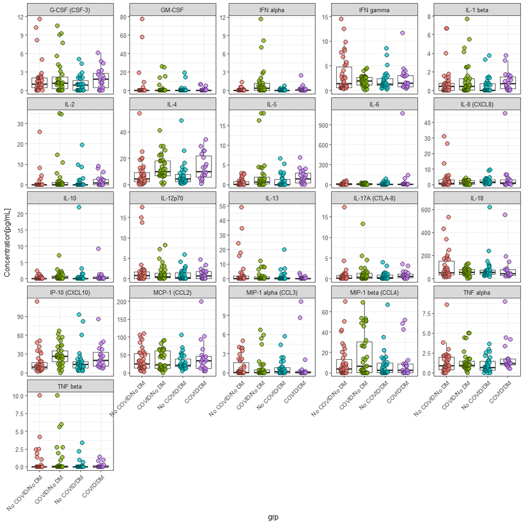

```r
ggplot(dt_elisa_l,
       aes(x = grp,
           y = `Concentration[pg/mL]`)) +
  facet_wrap(~ Protein,
             scale = "free_y") +
  geom_boxplot(outlier.shape = "") +
  geom_point(aes(fill = grp,
                 group = `Real ID`,),
             shape = 21,
             size = 3,
             alpha = 0.7,
             position = position_dodge(0.3)) +
  theme_bw() +
  theme(legend.position = "none",
        axis.text.x = element_text(angle = 45,
                                   hjust = 1))
```

## Log10 protein concentrations

### Histogram

```r
# for (i in 4:ncol(dt_elisa)) {
#   hist(log10(dt_elisa[,
#                 c(i),
#                 with = FALSE][[1]] + 1),
#        20,
#        main = colnames(dt_elisa)[i])
# }

dt_elisa_l$Log10Conc <- log10(dt_elisa_l$`Concentration[pg/mL]` + 1)
```

### Boxplots

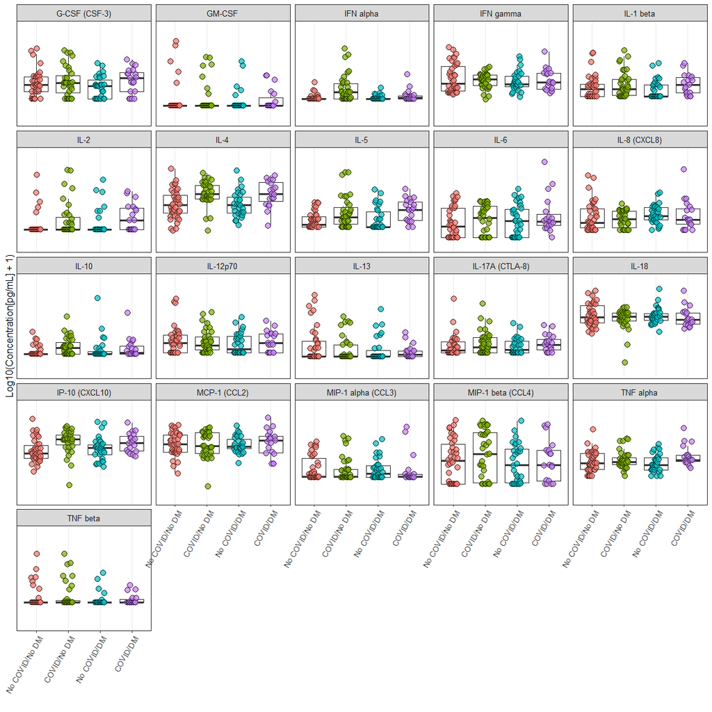

```r
ggplot(dt_elisa_l,
       aes(x = grp,
           y = Log10Conc)) +
  facet_wrap(~ Protein,
             scale = "free_y") +
  geom_boxplot(outlier.shape = "") +
  geom_point(aes(fill = grp,
                 group = `Real ID`,),
             shape = 21,
             size = 3,
             alpha = 0.7,
             position = position_dodge(0.3)) +
  scale_x_discrete("") +
  scale_y_discrete("Log10(Concentration[pg/mL] + 1)") +
  theme_bw() +
  theme(legend.position = "none",
        axis.text.x = element_text(angle = 60,
                                   hjust = 1))
```

```r
# out <- list()
# for (i in 4:ncol(dt_elisa)) {
#
#   tmp <- data.table(id = dt_elisa$`Real ID`,
#                     covid = dt_elisa$`Study Group`,
#                     dm = factor(dt_elisa$AnyDM,
#                                 levels = 0:1,
#                                 labels = c("No DM",
#                                            "DM")),
#                     resp = log10(dt_elisa[, c(i), with = FALSE][[1]] + 0.01))
#
#   p1 <- ggplot(tmp,
#                aes(x = covid,
#                    y = resp)) +
#     facet_wrap(~ dm) +
#     geom_boxplot(outlier.shape = "") +
#     geom_point(aes(fill = covid,
#                    group = id,),
#                shape = 21,
#                size = 3,
#                alpha = 0.7,
#                position = position_dodge(0.3)) +
#     ggtitle(colnames(dt_elisa)[i]) +
#     theme_bw()
#   print(p1)
#
#   s1 <- summary(lm(resp ~ covid*dm,
#                    data = tmp))
#
#   out[[i- 3]] <- data.table(protein = colnames(dt_elisa)[i],
#                             comparison = c("COVID - non-COVID",
#                                            "DM - non-DM",
#                                            "COVID*DM Interaction"),
#                             diff = round(s1$coefficients[-1, 1], 3),
#                             se_diff = round(s1$coefficients[-1, 2], 3),
#                             pval = round(s1$coefficients[-1, 4], 3))
# }
```

## ELISA Two Part model

```r
foo <- function(dx) {
  return(tpm(formula_part1 = Log10Conc ~ `Study Group`*AnyDM,
             formula_part2 = NULL,
             link_part1 = "logit",
             family_part2 = gaussian(link = "identity"),
             data = dx))
}

m1 <- dt_elisa_l[, .(models = list(tpm(formula_part1 = Log10Conc ~ grp,
                                       formula_part2 = NULL,
                                       link_part1 = "logit",
                                       family_part2 = gaussian(link = "identity"),
                                       data = data.table(Log10Conc = Log10Conc,
                                                         grp = grp)))),
                 by = Protein]

# m1$Protein
#
# mm1 <- m1$models[[1]]
# s1 <- summary(mm1)
# s1
#
# est_ame <- AME(object = mm1,
#                se.method = "delta")
#
# est_ame <- AME(object = mm1,
#                se.method = "bootstrap")
# est_ame
```

```r
# m1$Protein
#
# mm1 <- m1$models[[1]]
# s1 <- summary(mm1)
# s1
#
# est_ame <- AME(object = mm1,
#                se.method = "delta")
#
# est_ame <- AME(object = mm1,
#                se.method = "bootstrap")
# est_ame
```

```r
out <- lapply(m1$models,
              function(a) {
                try({
                  s1 <- summary(a)

                  # Average Marginal Effect
                  # est_ame <- AME(object = a,
                  #                se.method = "bootstrap")
                  # NOTE: convergence issues iwth bootstrap!

                  est_ame <- AME(object = a,
                                 se.method = "delta")

                  rbindlist(list(data.table(Model = "Logistic",
                                            Comparisons = c("COVID/No DM - No COVID/No DM",
                                                            "No COVID/DM - No COVID/No DM",
                                                            "COVID/DM - No COVID/No DM"),
                                            Estimated = "Odds Ratio of Finding the Protein (non-zero)",
                                            Estimate = exp(s1$Firstpart.model$coefficients[-1, 1]),
                                            CILB = exp(s1$Firstpart.model$coefficients[-1, 1] -
                                                         1.96*s1$Firstpart.model$coefficients[-1, 2]),
                                            CIUB = exp(s1$Firstpart.model$coefficients[-1, 1] +
                                                         1.96*s1$Firstpart.model$coefficients[-1, 2]),
                                            pVal = s1$Firstpart.model$coefficients[-1, 4]),

                                 data.table(Model = "Gaussian",
                                            Comparisons = c("COVID/No DM - No COVID/No DM",
                                                            "No COVID/DM - No COVID/No DM",
                                                            "COVID/DM - No COVID/No DM"),
                                            Estimated = "Log10(Concentration [pg/mL] + 1) Difference",
                                            Estimate = s1$Secondpart.model$coefficients[-1, 1],
                                            CILB = s1$Secondpart.model$coefficients[-1, 1] -
                                              1.96*s1$Secondpart.model$coefficients[-1, 2],
                                            CIUB = s1$Secondpart.model$coefficients[-1, 1] +
                                              1.96*s1$Secondpart.model$coefficients[-1, 2],
                                            pVal = s1$Secondpart.model$coefficients[-1, 4]),
                                 data.table(Model = "Average Marginal Effect",
                                            Comparisons = c("COVID/No DM - No COVID/No DM",
                                                            "No COVID/DM - No COVID/No DM",
                                                            "COVID/DM - No COVID/No DM"),
                                            Estimated = "Log10(Concentration [pg/mL] + 1) Difference",
                                            Estimate = est_ame$dydx,
                                            CILB = est_ame$CI.L,
                                            CIUB = est_ame$CI.U,
                                            pVal = est_ame$pvalue)))
                })
              })

out <- do.call("rbind",
               out)

out <- data.table(Protein = rep(m1$Protein,
                                each = 9),
                  out)

write.csv(out,
          "../tmp/two_part_models_elisa.csv",
          row.names = FALSE)
head(out)
```

| Protein | Model | Comparisons | Estimated | Estimate | CILB | CIUB | pVal |
| --- | --- | --- | --- | --- | --- | --- | --- |
| G-CSF (CSF-3) | Logistic | COVID/No DM - No COVID/No DM | Odds Ratio of Finding the Protein (non-zero) | 0.90000000 | 0.29678576 | 2.72924150 | 0.8523309 |
| G-CSF (CSF-3) | Logistic | No COVID/DM - No COVID/No DM | Odds Ratio of Finding the Protein (non-zero) | 0.62222222 | 0.20636642 | 1.87608280 | 0.3994485 |
| G-CSF (CSF-3) | Logistic | COVID/DM - No COVID/No DM | Odds Ratio of Finding the Protein (non-zero) | 1.00000000 | 0.25902357 | 3.86065246 | 1.0000000 |
| G-CSF (CSF-3) | Gaussian | COVID/No DM - No COVID/No DM | Log10(Concentration [pg/mL] + 1) Difference | 0.05742506 | -0.06775114 | 0.18260127 | 0.3709951 |
| G-CSF (CSF-3) | Gaussian | No COVID/DM - No COVID/No DM | Log10(Concentration [pg/mL] + 1) Difference | -0.06045090 | -0.19470937 | 0.07380756 | 0.3798812 |
| G-CSF (CSF-3) | Gaussian | COVID/DM - No COVID/No DM | Log10(Concentration [pg/mL] + 1) Difference | 0.06977557 | -0.07944438 | 0.21899551 | 0.3618814 |

```r
out$Estimate[is.infinite(out$CIUB)] <-  NA
out$CILB[is.infinite(out$CIUB)] <-  NA
out$CIUB[is.infinite(out$CIUB)] <- NA
```

### Logistic

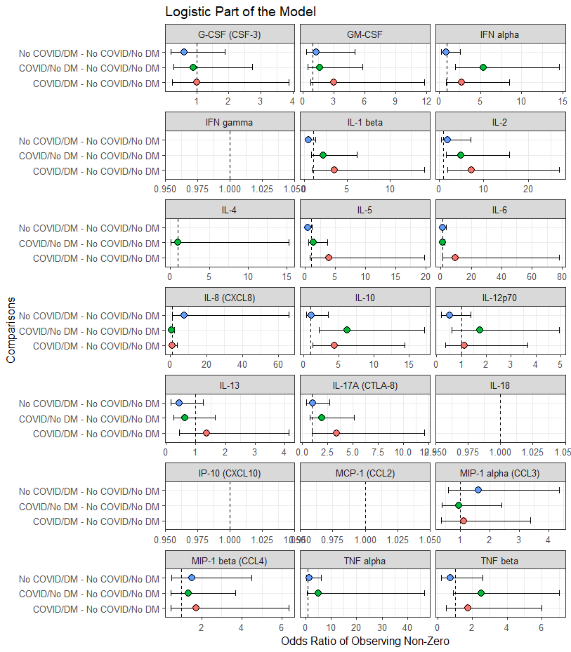

```r
p1 <- ggplot(data = out[Model == "Logistic", ],
             aes(x = Estimate,
                 xmin = CILB,
                 xmax = CIUB,
                 y = Comparisons,
                 fill = Comparisons)) +
  facet_wrap(~ Protein,
             scale = "free_x",
             ncol = 3) +
  geom_errorbarh(height = 0.4) +
  geom_vline(xintercept = 1,
             linetype = "dashed") +
  geom_point(shape = 21,
             size = 3) +
  scale_x_continuous("Odds Ratio of Observing Non-Zero") +
  ggtitle("Logistic Part of the Model") +
  theme_bw() +
  theme(legend.position = "none")

tiff(filename = "../tmp/elisa_two_part_logist.tiff",
     height = 8,
     width = 7,
     units = 'in',
     res = 600,
     compression = "lzw+p")
print(p1)
graphics.off()

p1
```

### Gaussian

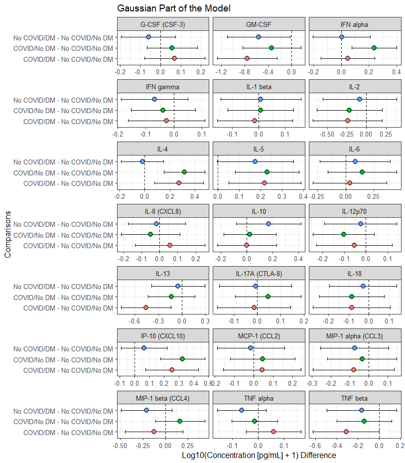

```r
p1 <- ggplot(data = out[Model == "Gaussian", ],
             aes(x = Estimate,
                 xmin = CILB,
                 xmax = CIUB,
                 y = Comparisons,
                 fill = Comparisons)) +
  facet_wrap(~ Protein,
             scale = "free_x",
             ncol = 3) +
  geom_errorbarh(height = 0.3) +
  geom_vline(xintercept = 0,
             linetype = "dashed") +
  geom_point(shape = 21,
             size = 3) +
  scale_x_continuous("Log10(Concentration [pg/mL] + 1) Difference") +
  ggtitle("Gaussian Part of the Model") +
  theme_bw() +
  theme(legend.position = "none")

tiff(filename = "../tmp/elisa_two_part_gaussian.tiff",
     height = 8,
     width = 7,
     units = 'in',
     res = 600,
     compression = "lzw+p")
print(p1)
graphics.off()

p1
```

### Average Marginal Effect

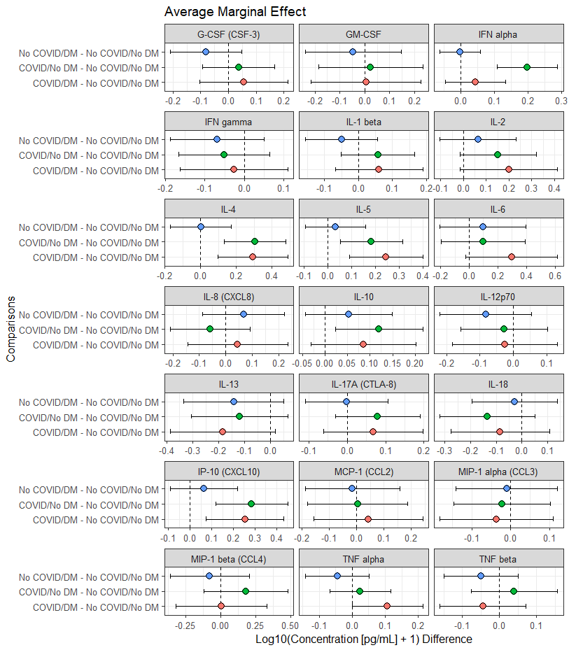

```r
p1 <- ggplot(data = out[Model == "Average Marginal Effect", ],
             aes(x = Estimate,
                 xmin = CILB,
                 xmax = CIUB,
                 y = Comparisons,
                 fill = Comparisons)) +
  facet_wrap(~ Protein,
             scale = "free_x",
             ncol = 3) +
  geom_errorbarh(height = 0.3) +
  geom_vline(xintercept = 0,
             linetype = "dashed") +
  geom_point(shape = 21,
             size = 3) +
  scale_x_continuous("Log10(Concentration [pg/mL] + 1) Difference") +
  ggtitle("Average Marginal Effect") +
  theme_bw() +
  theme(legend.position = "none")

tiff(filename = "../tmp/elisa_two_part_average_marginal_effect.tiff",
     height = 8,
     width = 7,
     units = 'in',
     res = 600,
     compression = "lzw+p")
print(p1)
graphics.off()

p1
```

## ELISA binarized

| Real ID | Study Group | AnyDM | G-CSF (CSF-3) | GM-CSF | IFN alpha | IFN gamma | IL-1 beta | IL-2 | IL-4 | IL-5 | IL-6 | IL-8 (CXCL8) | IL-10 | IL-12p70 | IL-13 | IL-17A (CTLA-8) | IL-18 | IP-10 (CXCL10) | MCP-1 (CCL2) | MIP-1 alpha (CCL3) | MIP-1 beta (CCL4) | TNF alpha | TNF beta |
| --- | --- | --- | --- | --- | --- | --- | --- | --- | --- | --- | --- | --- | --- | --- | --- | --- | --- | --- | --- | --- | --- | --- | --- |
| 136869 | COVID | 1 | 1 | 1 | 1 | 1 | 1 | 1 | 1 | 1 | 1 | 0 | 1 | 1 | 1 | 1 | 1 | 1 | 1 | 1 | 1 | 1 | 0 |
| 145303 | COVID | 1 | 1 | 1 | 1 | 1 | 1 | 1 | 1 | 1 | 1 | 1 | 1 | 1 | 1 | 1 | 1 | 1 | 1 | 1 | 1 | 1 | 1 |
| 162361 | COVID | 0 | 1 | 1 | 1 | 1 | 1 | 1 | 1 | 1 | 1 | 1 | 1 | 1 | 1 | 1 | 1 | 1 | 1 | 0 | 1 | 1 | 1 |
| 169232 | COVID | 0 | 1 | 0 | 1 | 1 | 0 | 0 | 1 | 1 | 1 | 1 | 1 | 0 | 0 | 0 | 1 | 1 | 1 | 1 | 1 | 1 | 0 |
| 170984 | COVID | 1 | 1 | 0 | 0 | 1 | 1 | 1 | 1 | 1 | 1 | 0 | 0 | 1 | 1 | 1 | 1 | 1 | 1 | 0 | 0 | 1 | 0 |
| 172112 | COVID | 1 | 1 | 0 | 0 | 1 | 1 | 0 | 1 | 1 | 1 | 1 | 1 | 1 | 1 | 1 | 1 | 1 | 1 | 1 | 1 | 1 | 0 |
| 223420 | COVID | 0 | 1 | 0 | 1 | 1 | 1 | 0 | 1 | 0 | 1 | 1 | 1 | 0 | 0 | 0 | 1 | 1 | 1 | 1 | 1 | 1 | 0 |
| 322840 | COVID | 0 | 1 | 1 | 1 | 1 | 1 | 1 | 1 | 1 | 1 | 1 | 1 | 1 | 1 | 1 | 1 | 1 | 1 | 1 | 1 | 1 | 1 |
| 341512 | COVID | 0 | 1 | 0 | 0 | 1 | 0 | 0 | 1 | 0 | 0 | 0 | 0 | 0 | 0 | 1 | 1 | 1 | 1 | 0 | 1 | 1 | 0 |
| 352486 | COVID | 0 | 1 | 0 | 1 | 1 | 1 | 1 | 1 | 1 | 0 | 1 | 1 | 1 | 0 | 1 | 1 | 1 | 1 | 0 | 1 | 1 | 0 |

[output cut: 112 more lines]

```r
m1 <- factanal(x = dt_elisa[, 4:ncol(dt_elisa)],
               factors = 1)

m1
```

```
Call:
factanal(x = dt_elisa[, 4:ncol(dt_elisa)], factors = 1)

Uniquenesses:
     G-CSF (CSF-3)             GM-CSF          IFN alpha          IFN gamma
             0.361              0.287              0.871              0.755
         IL-1 beta               IL-2               IL-4               IL-5
             0.487              0.324              0.785              0.550
              IL-6       IL-8 (CXCL8)              IL-10           IL-12p70
             0.954              0.940              0.918              0.437
             IL-13    IL-17A (CTLA-8)              IL-18     IP-10 (CXCL10)
             0.495              0.515              0.909              0.904
      MCP-1 (CCL2) MIP-1 alpha (CCL3)  MIP-1 beta (CCL4)          TNF alpha
             0.951              0.864              0.839              0.324
          TNF beta
             0.206

Loadings:
                   Factor1
G-CSF (CSF-3)      0.799
GM-CSF             0.844
IFN alpha          0.359
IFN gamma          0.495
IL-1 beta          0.716
IL-2               0.822
IL-4               0.464
IL-5               0.671
IL-6               0.213
IL-8 (CXCL8)       0.244
IL-10              0.287
IL-12p70           0.750
IL-13              0.711
IL-17A (CTLA-8)    0.696
IL-18              0.302
IP-10 (CXCL10)     0.310
MCP-1 (CCL2)       0.222
MIP-1 alpha (CCL3) 0.368
MIP-1 beta (CCL4)  0.401
TNF alpha          0.822
TNF beta           0.891

               Factor1
SS loadings      7.324
Proportion Var   0.349

Test of the hypothesis that 1 factor is sufficient.
The chi square statistic is 1377.12 on 189 degrees of freedom.
The p-value is 0.0000000000000000000000000000000000000000000000000000000000000000000000000000000000000000000000000000000000000000000000000000000000000000000000000000000000000000000000000000000000211
```

```r
m2 <- factanal(x = dt_elisa[, 4:ncol(dt_elisa)],
               factors = 2)

m2
```

```
Call:
factanal(x = dt_elisa[, 4:ncol(dt_elisa)], factors = 2)

Uniquenesses:
     G-CSF (CSF-3)             GM-CSF          IFN alpha          IFN gamma
             0.360              0.240              0.882              0.607
         IL-1 beta               IL-2               IL-4               IL-5
             0.453              0.326              0.659              0.568
              IL-6       IL-8 (CXCL8)              IL-10           IL-12p70
             0.447              0.259              0.731              0.387
             IL-13    IL-17A (CTLA-8)              IL-18     IP-10 (CXCL10)
             0.458              0.467              0.702              0.547
      MCP-1 (CCL2) MIP-1 alpha (CCL3)  MIP-1 beta (CCL4)          TNF alpha
             0.771              0.572              0.671              0.212
          TNF beta
             0.192

Loadings:
                   Factor1 Factor2
G-CSF (CSF-3)       0.775   0.198
GM-CSF              0.864   0.114
IFN alpha           0.322   0.119
IFN gamma           0.354   0.517
IL-1 beta           0.735
IL-2                0.799   0.187
IL-4                0.314   0.492
IL-5                0.620   0.220
IL-6                        0.743
IL-8 (CXCL8)                0.860
IL-10               0.120   0.505
IL-12p70            0.778
IL-13               0.730
IL-17A (CTLA-8)     0.728
IL-18               0.146   0.526
IP-10 (CXCL10)              0.667
MCP-1 (CCL2)                0.474
MIP-1 alpha (CCL3)  0.166   0.633
MIP-1 beta (CCL4)   0.237   0.523
TNF alpha           0.683   0.567
TNF beta            0.884   0.164

               Factor1 Factor2
SS loadings      6.289   4.200
Proportion Var   0.299   0.200
Cumulative Var   0.299   0.499

Test of the hypothesis that 2 factors are sufficient.
The chi square statistic is 1031.82 on 169 degrees of freedom.
The p-value is 0.000000000000000000000000000000000000000000000000000000000000000000000000000000000000000000000000000000000000000000000000000916
```

```r
m3 <- factanal(x = dt_elisa[, 4:ncol(dt_elisa)],
               factors = 3)

m3
```

```
Call:
factanal(x = dt_elisa[, 4:ncol(dt_elisa)], factors = 3)

Uniquenesses:
     G-CSF (CSF-3)             GM-CSF          IFN alpha          IFN gamma
             0.368              0.103              0.645              0.528
         IL-1 beta               IL-2               IL-4               IL-5
             0.467              0.137              0.660              0.017
              IL-6       IL-8 (CXCL8)              IL-10           IL-12p70
             0.458              0.257              0.717              0.332
             IL-13    IL-17A (CTLA-8)              IL-18     IP-10 (CXCL10)
             0.227              0.461              0.652              0.548
      MCP-1 (CCL2) MIP-1 alpha (CCL3)  MIP-1 beta (CCL4)          TNF alpha
             0.749              0.573              0.669              0.231
          TNF beta
             0.194

Loadings:
                   Factor1 Factor2 Factor3
G-CSF (CSF-3)       0.567   0.178   0.528
GM-CSF              0.922   0.128   0.178
IFN alpha                           0.586
IFN gamma           0.413   0.549
IL-1 beta           0.659           0.301
IL-2                0.557   0.135   0.731
IL-4                0.195   0.488   0.253
IL-5                0.229   0.143   0.954
IL-6                        0.726   0.103
IL-8 (CXCL8)                0.862
IL-10                       0.489   0.209
IL-12p70            0.795   0.112   0.153
IL-13               0.869   0.131
IL-17A (CTLA-8)     0.718           0.134
IL-18               0.200   0.553
IP-10 (CXCL10)              0.667
MCP-1 (CCL2)        0.110   0.486
MIP-1 alpha (CCL3)          0.620   0.188
MIP-1 beta (CCL4)   0.218   0.523
TNF alpha           0.546   0.558   0.399
TNF beta            0.725   0.151   0.507

               Factor1 Factor2 Factor3
SS loadings      5.024   4.163   2.820
Proportion Var   0.239   0.198   0.134
Cumulative Var   0.239   0.437   0.572

Test of the hypothesis that 3 factors are sufficient.
The chi square statistic is 757.68 on 150 degrees of freedom.
The p-value is 0.00000000000000000000000000000000000000000000000000000000000000000000000000000000071
```

## LM results

```r
res <- rbindlist(out)
# res$pval[res$pval == 0] <- "<0.001"
res
```

## ELISA PCA

### PCA

```r
m1 <- prcomp(dt_elisa[, -c(1:3)],
             center = TRUE,
             scale. = TRUE)
summary(m1)
```

### Scores (i.e. points)

```r
dt_scr <- data.table(m1$x[, 1:2])
dt_scr$covid <- dt_elisa$`Study Group`
dt_scr$dm <- factor(dt_elisa$AnyDM,
                    levels = 0:1,
                    labels = c("No DM",
                               "DM"))
head(dt_scr)
```

### Loading (i.e. arrows)

```r
dt_rot <- as.data.frame(m1$rotation[, 1:2])
dt_rot$feat <- rownames(dt_rot)
dt_rot <- data.table(dt_rot)
dt_rot
```

### Axis labels

```r
u.axis.labs <- paste(colnames(dt_rot)[1:2],
                     sprintf('(%0.1f%% explained var.)',
                             100*m1$sdev[1:2]^2/sum(m1$sdev^2)))
u.axis.labs
```

### Biplot by COVID

```r
grp <- dt_scr$covid
scl <- 30

p1 <- ggplot(data = dt_rot,
             aes(x = PC1,
                 y = PC2)) +
  coord_equal() +
  geom_point(data = dt_scr,
             aes(fill = grp),
             shape = 21,
             size = 3,
             alpha = 0.7) +
  geom_segment(aes(x = 0,
                   y = 0,
                   xend = scl*PC1,
                   yend = scl*PC2),
               arrow = arrow(length = unit(1/2, 'picas')),
               color = "black",
               size = 0.5) +
  geom_text(aes(x = 1.1*scl*PC1,
                y = 1.1*scl*PC2,
                label = dt_rot$feat),
            size = 2,
            hjust = 0.5) +
  scale_x_continuous(u.axis.labs[1]) +
  scale_y_continuous(u.axis.labs[2]) +
  scale_fill_discrete(name = "Group") +
  ggtitle("Biplot") +
  theme_bw() +
  theme(plot.title = element_text(hjust = 0.5,
                                  size = 20))
p1
# tiff(filename = "tmp/pca_biplot.tiff",
#      height = 10,
#      width = 10,
#      units = 'in',
#      res = 300,
#      compression = "lzw+p")
# print(p1)
# graphics.off()
```

```r
grp <- dt_scr$dm
scl <- 30

p1 <- ggplot(data = dt_rot,
             aes(x = PC1,
                 y = PC2)) +
  coord_equal() +
  geom_point(data = dt_scr,
             aes(fill = grp),
             shape = 21,
             size = 3,
             alpha = 0.7) +
  geom_segment(aes(x = 0,
                   y = 0,
                   xend = scl*PC1,
                   yend = scl*PC2),
               arrow = arrow(length = unit(1/2, 'picas')),
               color = "black",
               size = 0.5) +
  geom_text(aes(x = 1.1*scl*PC1,
                y = 1.1*scl*PC2,
                label = dt_rot$feat),
            size = 2,
            hjust = 0.5) +
  scale_x_continuous(u.axis.labs[1]) +
  scale_y_continuous(u.axis.labs[2]) +
  scale_fill_discrete(name = "Group") +
  ggtitle("Biplot") +
  theme_bw() +
  theme(plot.title = element_text(hjust = 0.5,
                                  size = 20))
p1
# tiff(filename = "tmp/pca_biplot.tiff",
#      height = 10,
#      width = 10,
#      units = 'in',
#      res = 300,
#      compression = "lzw+p")
# print(p1)
# graphics.off()
```

# RNA-seq

https://bioconductor.org/packages/devel/bioc/vignettes/DESeq2/inst/doc/DESeq2.html

## Merge RNA-seq meta-data with clinical

```r
rnaseq_meta_clin <- merge(rnaseq_meta,
                          dt1[, c("Real ID",
                                  "Study Group",
                                  "Expired",
                                  "Critical Care",
                                  "Age",
                                  "Sex",
                                  "Race",
                                  "BMI",
                                  "AnyDM")],
                          by = "Real ID")

names(rnaseq_meta_clin)[3] <- "Cohort"
rnaseq_meta_clin$Cohort <- gsub(x = rnaseq_meta_clin$Cohort,
                                pattern = " ",
                                replacement = "_")
rnaseq_meta_clin$Cohort <- factor(rnaseq_meta_clin$Cohort,
                                  levels = c("No_COVID",
                                             "COVID"))
```

## Fragments Per Million (FPM)

### Sequencing depth

```r
seq_d <- colSums(dt_rna[, -c(1:11)])
hist(seq_d, 20)
```

### DESeq: all genes

```r
ndx <- which(colnames(dt_rna) %in% rnaseq_meta_clin$sample_names)

tmp <- as.matrix(dt_rna[, ndx, with = FALSE])
rownames(tmp) <- dt_rna$gene_id

dds_all <- DESeqDataSetFromMatrix(countData = tmp,
                                  colData = rnaseq_meta_clin,
                                  design = ~ 1)
dds_all
```

### FPM

```r
dt_fpm <- fpm(object = dds_all,
              robust = FALSE)
dt_fpm[1:10, 1:5]
colSums(dt_fpm)[1:5]
```

```r
tmp5

xx <- data.table(fpm = dt_fpm[which(rownames(dt_fpm) == "ENSG00000165949"), ],
                 sample_names = colnames(dt_fpm))

xx <- merge(xx,
            rnaseq_meta_clin,
            by = "sample_names")
xx

boxplot(log10(xx$fpm + 1) ~ xx$Cohort)
```

## Protein coding genes only

```r
dt_rna_cod <- dt_rna[gene_biotype == "protein_coding",]
```

## Select samples with clinical information

```r
ndx <- which(colnames(dt_rna_cod) %in% rnaseq_meta_clin$sample_names)
```

## DESeq

```r
tmp <- as.matrix(dt_rna_cod[, ndx, with = FALSE])
rownames(tmp) <- dt_rna_cod$gene_id

dds_cod <- DESeqDataSetFromMatrix(countData = tmp,
                                  colData = rnaseq_meta_clin,
                                  ~ 1)
```

## Filter out genes with small number of hits

```r
# Number of samples with at least 10 hits in at least X samples
min_n_hits <- c(1, 5, 10, 20, 50)

l2 <- list()

for (j in 1:length(min_n_hits)) {

  l1 <- list()

  for (i in 1:length(ndx)) {

    l1[[i]] <- data.table(`Min N of hits per sample` = min_n_hits[j],
                          `N samples with min hits or more` = i,
                          `N genes` = sum(rowSums(counts(dds_cod) >= j) >= i))
  }
  l2[[j]] <- do.call("rbind",
                     l1)
}

ll <- do.call("rbind",
              l2)
ll$`Min N of hits per sample` <- factor(ll$`Min N of hits per sample`,
                                        levels = min_n_hits)
```

```r
ll$lw <- 0.5
ll$lw[ll$`Min N of hits per sample` == 10] <- 1.5

ggplot(ll,
       aes(x = `N samples with min hits or more`,
           y = `N genes`,
           group = `Min N of hits per sample`,
           color = `Min N of hits per sample`)) +
  geom_line(linewidth = ll$lw) +
  geom_vline(xintercept = 10,
             linetype = "dashed",
             color = "red") +
  scale_x_continuous(breaks = seq(0, 92, 5)) +
  theme_bw()
```

```r
keep <- rowSums(counts(dds_cod) >= 10) >= 10
sum(keep)

dds_cod <- dds_cod[keep, ]
```

## COVID/non-COOVID

### Restructure design (model)

```r
design(dds_cod) <- ~ Cohort
```

### Run DESeq

```r
deseq_cod <- DESeq(dds_cod)
resultsNames(deseq_cod)
```

### Results

```r
res <- results(deseq_cod)
res[1:10, ]
rownames(res)[1:10]
```

```r
out <- data.table(gene_id = rownames(res),
                  baseMean = res$baseMean,
                  log2FoldChange = res$log2FoldChange,
                  log2FoldChangeSE = res$lfcSE,
                  stat = res$stat,
                  pvalue = res$pvalue,
                  padj = res$padj)

out <- merge(dt_rna_cod[, c("gene_name",
                            "gene_id")],
             out,
             by = "gene_id")

out <- out[!is.na(padj), ]

setorder(out,
         padj)


head(out)

write.csv(out,
          file = "tmp/deseq2_cod_covid_nocovid.CSV",
          row.names = FALSE)
```

```r
tmp5 <- out[abs(log2FoldChange) > 1 &
              padj < 0.05, ]
#
# tmp5_up <- out[log2FoldChange > 1 &
#               padj < 0.05, ]
#
# tmp5_down <- out[log2FoldChange < -1 &
#               padj < 0.05, ]
```

### Calculate the mean expressions of the selected genes

```r
tmp <- dt_rna_cod[gene_name %in% tmp5$gene_name, ]
tmp <- melt.data.table(data = tmp,
                       id.vars = 1,
                       measure.vars = 12:ncol(tmp),
                       variable.name = "sample_names",
                       value.name = "Hits")

tmp <- merge(tmp,
             rnaseq_meta_clin,
             by = "sample_names")
```

```r
p1 <- ggplot(tmp,
             aes(x = Cohort,
                 y = log2(Hits + 1))) +
  facet_wrap(~ gene_name,
             scale = "free_y") +
  geom_boxplot(width = 0.3,
               outlier.shape = "") +
  geom_point(aes(fill = AnyDM,
                 group = sample_names),
             size = 2,
             shape = 21,
             alpha = 0.5,
             position = position_dodge(0.3)) +
  scale_y_continuous("Number of hits",
                     breaks = seq(from = 1,
                                  to = 20,
                                  by = 2),
                     labels = (2^seq(from = 1,
                                     to = 20,
                                     by = 2)) - 1) +
  scale_fill_discrete("Any DM",
                      breaks = c(0, 1),
                      labels = c("No",
                                 "Yes")) +
  ggtitle(paste(c("Genes significantly differentially expressed in COVID-19 vs non-COVID patients.",
                  "Difference of the means of log2[hits+1] > 1 and adjusted p-value < 0.05"),
                collapse = "\n"))+
  theme_bw() +
  theme(legend.position = "bottom")

tiff(filename = "tmp/fig1_sign_genes_cod.tiff",
     height = 10,
     width = 10,
     units = 'in',
     res = 600,
     compression = "lzw+p")
print(p1)
graphics.off()

p1
```

```r
p2 <- ggplot(tmp[gene_name == "IFI27", ],
             aes(x = Cohort,
                 y = log2(Hits + 1))) +
  geom_boxplot(width = 0.3,
               outlier.shape = "") +
  geom_point(aes(fill = Expired,
                 group = sample_names),
             size = 3,
             shape = 21,
             alpha = 0.8,
             position = position_dodge(0.3)) +
  scale_y_continuous("Number of hits",
                     breaks = seq(from = 1,
                                  to = 20,
                                  by = 2),
                     labels = (2^seq(from = 1,
                                     to = 20,
                                     by = 2)) - 1) +
  scale_fill_discrete("In-Hospital Death",
                      breaks = c(0, 1),
                      labels = c("No",
                                 "Yes")) +
  ggtitle(paste(c("IFI27 expression in COVID-19 vs non-COVID patients.",
                  "Difference of the means of log2[hits+1] > 1",
                  "and adjusted p-value < 0.05"),
                collapse = "\n")) +
  theme_bw() +
  theme(legend.position = "bottom")

p3 <- ggplot(tmp[gene_name == "IFI27", ],
             aes(x = Cohort,
                 y = log2(Hits + 1))) +
  geom_boxplot(width = 0.3,
               outlier.shape = "") +
  geom_point(aes(fill = `Critical Care`,
                 group = sample_names),
             size = 3,
             shape = 21,
             alpha = 0.8,
             position = position_dodge(0.3)) +
  scale_y_continuous("Number of hits",
                     breaks = seq(from = 1,
                                  to = 20,
                                  by = 2),
                     labels = (2^seq(from = 1,
                                     to = 20,
                                     by = 2)) - 1) +
  scale_fill_discrete("Critical Care",
                      breaks = c(0, 1),
                      labels = c("No",
                                 "Yes")) +
  ggtitle(paste(c("IFI27 expression in COVID-19 vs non-COVID patients.",
                  "Difference of the means of log2[hits+1] > 1",
                  "and adjusted p-value < 0.05"),
                collapse = "\n")) +
  theme_bw() +
  theme(legend.position = "bottom")

tiff(filename = "tmp/fig2_ifi27_covid_noncovid.tiff",
     height = 6,
     width = 9,
     units = 'in',
     res = 600,
     compression = "lzw+p")
grid.arrange(p2,
             p3,
             nrow = 1)
# grid.arrange(p2,
#              p3,
#              nrow = 1,
#              top = textGrob(paste(c("IFI27 expression in COVID-19 vs non-COVID patients.",
#                                     "Difference of the means of log2[hits+1] > 1",
#                                     "and adjusted p-value < 0.05"),
#                                   collapse = "\n"),
#                             gp = gpar(fontsize = 20,
#                                       font = 3)))
graphics.off()

grid.arrange(p2,
             p3,
             nrow = 1)
```

### Table 3: COVID/non-COVID significant DEs

```r
# mu <- tmp[, .(mu = exp(mean(log(Hits + 1))) - 1,
#               med = median(Hits)),
#               by = list(gene_name,
#                         Cohort)]
# mu

med <- tmp[, .(med = median(Hits)),
           by = list(gene_name,
                     Cohort)]
med <- dcast.data.table(data = med,
                        gene_name ~ Cohort,
                        value.var = "med")
med

t3 <- data.table(gene_name = tmp5$gene_name,
                 `Log2 Fold Change` = round(tmp5$log2FoldChange, 2),
                 `SE of Log2 Fold Change` = round(tmp5$log2FoldChangeSE, 2),
                 `Adjusted p-Value` = round(tmp5$padj, 3))

t3 <- merge(med,
            t3,
            by = "gene_name")

names(t3)[1:3] <- c("Gene",
                    "Median hits in non-COVID",
                    "Median hits in COVID")

write.csv(t3,
          file = "tmp/t3.csv",
          row.names = FALSE)
t3
```

### Reactom Pathway Analysis

#### Top 18 genes

Source: https://stackoverflow.com/questions/71131883/r-how-do-i-convert-gene-symbols-to-entrez-ids

##### Map gene names to Entrez IDs

```r
dt_rpa1 <- merge(dt_rna[!is.na(entrez_id),
                        c("gene_name",
                          "entrez_id")],
                 tmp5[, c("gene_name",
                          "log2FoldChange")])
```

##### Run Reactom PA

```r
rpa1 <- ReactomePA::enrichPathway(gene = dt_rpa1$entrez_id,
                                  readable = TRUE)

write.csv(rpa1@result,
          file = "tmp/Pathway Analysis of COVID19 18 differentially expresed genes.csv")

rpa1@result
```

##### Barplot of pathways

NOTE: by default only shows pathways with adjusted p-value <0.05

```r
barplot(rpa1,
        showCategory = 4,
        title = "")
```

```r
# viewPathway(pathName = rpa1@result$Description[1])

# for(i in 1:length(rpa1@result$Description)) {
#   viewPathway(pathName = rpa1@result$Description[i])
# }

geneList1 <- dt_rpa1$log2FoldChange
names(geneList1) <- dt_rpa1$entrez_id
geneList1

# tiff(filename = paste0("tmp/",
#                        rpa1@result$Description[1],
#                        ".tiff"),
#      height = 8,
#      width = 8,
#      units = 'in',
#      res = 300,
#      compression = "lzw+p")
viewPathway(pathName = rpa1@result$Description[17],
            readable = TRUE,
            foldChange = geneList1)
# graphics.off()

# for(i in 1:length(rpa1@result$Description)) {
# for(i in 1:10) {
#   try({
#     tiff(filename = paste0("tmp/",
#                            rpa1@result$Description[i],
#                            ".tiff"),
#          height = 8,
#          width = 8,
#          units = 'in',
#          res = 600,
#          compression = "lzw+p")
#     viewPathway(pathName = rpa1@result$Description[i],
#                 readable = TRUE,
#                 foldChange = geneList1)
#     graphics.off()
#   })
# }
```

##### Enrichment analysis based on the DisGeNET

https://www.disgenet.org/

COVID19 Data on DisGeNET:  
https://www.disgenet.org/covid/diseases/summary/

DisGeNET is a discovery platform containing one of the largest publicly available collections of genes and variants associated to human diseases ( Piñero et al., 2021; Piñero et al., 2019; Piñero et al., 2016; Piñero et al., 2015). DisGeNET integrates data from expert curated repositories, GWAS catalogues, animal models and the scientific literature. DisGeNET data are homogeneously annotated with controlled vocabularies and community-driven ontologies. Additionally, several original metrics are provided to assist the prioritization of genotype–phenotype relationships.

The current version of DisGeNET (v7.0) contains 1,134,942 gene-disease associations (GDAs), between 21,671 genes and 30,170 diseases, disorders, traits, and clinical or abnormal human phenotypes, and 369,554 variant-disease associations (VDAs), between 194,515 variants and 14,155 diseases, traits, and phenotypes.

```r
tt1 <- DOSE::enrichDGN(dt_rpa1$entrez_id)
tt1@result

# barplot(tt1)
```

#### Top 64 genes

```r
tmp6 <- out[abs(log2FoldChange) > 0.5 &
              padj < 0.1, ]
```

```r
gene_list_2 <- mapIds(org.Hs.eg.db,
                      keys = tmp6$gene_name,
                      column = "ENTREZID",
                      keytype = "SYMBOL")
gene_list_2
```

```r
rpa2 <- ReactomePA::enrichPathway(gene = gene_list_2,
                                  readable = TRUE)

write.csv(rpa2@result,
          file = "tmp/Pathway Analysis of COVID19 64 differentially expresed genes.csv")

rpa2@result
```

## AnyDM/no DM

```r
design(dds_cod) <- ~ AnyDM
```

### Run DESeq

```r
deseq_cod_dm <- DESeq(dds_cod)

resultsNames(deseq_cod_dm)
```

### DESeq results

```r
res_dm <- results(deseq_cod_dm)
res_dm[1:10, ]
rownames(res_dm)[1:10]
```

```r
out_dm <- data.table(gene_id = rownames(res_dm),
                     baseMean = res_dm$baseMean,
                     log2FoldChange = res_dm$log2FoldChange,
                     log2FoldChangeSE = res_dm$lfcSE,
                     stat = res_dm$stat,
                     pvalue = res_dm$pvalue,
                     padj = res_dm$padj)

out_dm <- merge(dt_rna_cod[, c("gene_name",
                               "gene_id")],
                out_dm,
                by = "gene_id")

out_dm <- out_dm[!is.na(padj), ]

setorder(out_dm,
         padj)


head(out_dm)

write.csv(out_dm,
          file = "tmp/deseq2_cod_dm.CSV",
          row.names = FALSE)
```

```r
tmp7 <- out_dm[abs(log2FoldChange) > 1 &
                 padj < 0.05, ]
```

### Calculate the mean expressions of the selected genes

```r
tmp <- dt_rna_cod[gene_name %in% tmp7$gene_name, ]
tmp <- melt.data.table(data = tmp,
                       id.vars = 1,
                       measure.vars = 12:ncol(tmp),
                       variable.name = "sample_names",
                       value.name = "Hits")

tmp <- merge(tmp,
             rnaseq_meta_clin,
             by = "sample_names")
```

### Table 4: DM/no DM significant DEs

```r
med <- tmp[, .(med = median(Hits)),
           by = list(gene_name,
                     Cohort)]
med <- dcast.data.table(data = med,
                        gene_name ~ Cohort,
                        value.var = "med")
med

t4 <- data.table(gene_name = tmp7$gene_name,
                 `Log2 Fold Change` = round(tmp7$log2FoldChange, 2),
                 `SE of Log2 Fold Change` = round(tmp7$log2FoldChangeSE, 2),
                 `Adjusted p-Value` = round(tmp7$padj, 3))

t4 <- merge(med,
            t4,
            by = "gene_name")

names(t4)[1:3] <- c("Gene",
                    "Median hits in non-COVID",
                    "Median hits in COVID")

write.csv(t4,
          file = "tmp/t4.csv",
          row.names = FALSE)
t4
```

```r
sum(t4$`Log2 Fold Change` > 0)
sum(t4$`Log2 Fold Change` < 0)
```

### Reactom PA

```r
gene_list_3 <- mapIds(org.Hs.eg.db,
                      keys = tmp7$gene_name,
                      column = "ENTREZID",
                      keytype = "SYMBOL")
length(gene_list_3)
```

```r
rpa3 <- ReactomePA::enrichPathway(gene = gene_list_3,
                                  readable = TRUE)

write.csv(rpa3@result,
          file = "tmp/Pathway Analysis of DM 431 differentially expresed genes.csv")

rpa3@result
```

## DM in COVID/non-COVID

### Prepare DDS

```r
ndx1 <- which(colnames(dt_rna_cod) %in% rnaseq_meta_clin$sample_names[rnaseq_meta_clin$AnyDM == 1])

tmp <- as.matrix(dt_rna_cod[,
                            ndx1,
                            with = FALSE])
dim(tmp)
rownames(tmp) <- dt_rna_cod$gene_id

dds_dm <- DESeqDataSetFromMatrix(countData = tmp,
                                  colData = rnaseq_meta_clin[rnaseq_meta_clin$AnyDM == 1, ],
                                  design = ~ Cohort)
dds_dm
```

### Run DESeq

```r
deseq_cod_dm <- DESeq(dds_dm)
resultsNames(deseq_cod_dm)
```

### Results

```r
res <- results(deseq_cod_dm)
res[1:10, ]
rownames(res)[1:10]
```

```r
out <- data.table(gene_id = rownames(res),
                  baseMean = res$baseMean,
                  log2FoldChange = res$log2FoldChange,
                  log2FoldChangeSE = res$lfcSE,
                  stat = res$stat,
                  pvalue = res$pvalue,
                  padj = res$padj)

out <- merge(dt_rna_cod[, c("gene_name",
                            "gene_id")],
             out,
             by = "gene_id")

out <- out[!is.na(padj), ]

setorder(out,
         padj)


head(out)

write.csv(out,
          file = "tmp/deseq2_cod_dm_only_covid_nocovid.CSV",
          row.names = FALSE)
```

```r
tmp8 <- out[abs(log2FoldChange) > 1 &
              padj < 0.05, ]
```

### Calculate the mean expressions of the selected genes

```r
tmp <- dt_rna_cod[gene_name %in% tmp8$gene_name, ]
tmp <- melt.data.table(data = tmp,
                       id.vars = 1,
                       measure.vars = 12:ncol(tmp),
                       variable.name = "sample_names",
                       value.name = "Hits")

tmp <- merge(tmp,
             rnaseq_meta_clin,
             by = "sample_names")
```

### Table 5: COVID/non-COVID, DM only

```r
med <- tmp[, .(med = median(Hits)),
           by = list(gene_name,
                     Cohort)]
med <- dcast.data.table(data = med,
                        gene_name ~ Cohort,
                        value.var = "med")
med

t5 <- data.table(gene_name = tmp8$gene_name,
                 `Log2 Fold Change` = round(tmp8$log2FoldChange, 2),
                 `SE of Log2 Fold Change` = round(tmp8$log2FoldChangeSE, 2),
                 `Adjusted p-Value` = round(tmp5$padj, 3))

t5 <- merge(med,
            t5,
            by = "gene_name")

names(t5)[1:3] <- c("Gene",
                    "Median hits in non-COVID",
                    "Median hits in COVID")

write.csv(t5,
          file = "tmp/t5.csv",
          row.names = FALSE)
t5
```

### Reactom Pathway Analysis

##### Map gene names to Entrez IDs

```r
dt_rpa8 <- merge(dt_rna[!is.na(entrez_id),
                        c("gene_name",
                          "entrez_id")],
                 tmp8[, c("gene_name",
                          "log2FoldChange")])
```

##### Run Reactom PA

```r
rpa8 <- ReactomePA::enrichPathway(gene = dt_rpa8$entrez_id,
                                  readable = TRUE)

write.csv(rpa8@result,
          file = "tmp/Pathway Analysis of COVID vs non-COVID differentially expresed genes in DM.csv")

rpa8@result
```

# !CONTINUE HERE 2/22/24!

### DE in COVID and DM

```r
covid_and_dm <- t4$Gene[t4$Gene %in% t3$Gene]
covid_and_dm
```

```r
dt_f3 <- dt_rna_cod[gene_name %in% covid_and_dm, ]

dt_f3 <- melt.data.table(data = dt_f3,
                         id.vars = 1,
                         measure.vars = 11:ncol(dt_f3),
                         variable.name = "sample_names",
                         value.name = "Hits")
dt_f3 <- merge(dt_f3,
               rnaseq_meta_clin,
               by = "sample_names")
```

```r
p4 <- ggplot(dt_f3,
             aes(x = Cohort,
                 y = log2(Hits + 1))) +
  facet_wrap(~ gene_name,
             scale = "free_y",
             ncol = 1) +
  geom_boxplot(width = 0.3,
               outlier.shape = "") +
  geom_point(aes(fill = AnyDM,
                 group = sample_names),
             size = 2,
             shape = 21,
             alpha = 0.7,
             position = position_dodge(0.3)) +
  scale_x_discrete("COVID",
                   breaks = c("No_COVID",
                              "COVID"),
                   labels = c("No",
                              "Yes")) +
  scale_y_continuous("Number of hits",
                     breaks = seq(from = 1,
                                  to = 20,
                                  by = 2),
                     labels = (2^seq(from = 1,
                                     to = 20,
                                     by = 2)) - 1) +
  scale_fill_discrete("Any DM",
                      breaks = c(0, 1),
                      labels = c("No",
                                 "Yes")) +
  theme_bw() +
  theme(legend.position = "bottom")

p5 <- ggplot(dt_f3,
             aes(x = AnyDM,
                 y = log2(Hits + 1))) +
  facet_wrap(~ gene_name,
             scale = "free_y",
             ncol = 1) +
  geom_boxplot(width = 0.3,
               outlier.shape = "") +
  geom_point(aes(fill = Cohort,
                 group = sample_names),
             size = 2,
             shape = 21,
             alpha = 0.7,
             position = position_dodge(0.3)) +
  scale_x_discrete("Any DM",
                   breaks = c(0, 1),
                   labels = c("No",
                              "Yes")) +
  scale_y_continuous("Number of hits",
                     breaks = seq(from = 1,
                                  to = 20,
                                  by = 2),
                     labels = (2^seq(from = 1,
                                     to = 20,
                                     by = 2)) - 1) +
  scale_fill_discrete("COVID",
                      breaks = c("No_COVID",
                                 "COVID"),
                      labels = c("No",
                                 "Yes")) +
  theme_bw() +
  theme(legend.position = "bottom")

tiff(filename = "tmp/fig3_covid_dm.tiff",
     height = 10,
     width = 6,
     units = 'in',
     res = 600,
     compression = "lzw+p")
grid.arrange(p4,
             p5,
             nrow = 1)
graphics.off()

grid.arrange(p4,
             p5,
             nrow = 1)
```

### DESeq: AnyDM/no DM in COVID patients only

```r
samples_covid_only <- rnaseq_meta_clin$sample_names[rnaseq_meta_clin$Cohort == "COVID"]
ndx_covid_only <- which(colnames(dt_rna_cod) %in% samples_covid_only)

tmp <- as.matrix(dt_rna_cod[, ndx_covid_only, with = FALSE])
rownames(tmp) <- dt_rna_cod$gene_id

dds_cod_dm_covid_only <- DESeqDataSetFromMatrix(countData = tmp,
                                                colData = rnaseq_meta_clin[sample_names %in% samples_covid_only],
                                                ~ AnyDM)
```

#### Filter out genes with small number of hits

```r
keep <- rowSums(counts(dds_cod_dm_covid_only) >= 10) >= 10
sum(keep)

dds_cod_dm_covid_only <- dds_cod_dm_covid_only[keep, ]
```

#### Run DESeq

```r
deseq_cod_dm_covid_only <- DESeq(dds_cod_dm_covid_only)

resultsNames(deseq_cod_dm_covid_only)
```

#### DESeq results

```r
res_dm_covid_only <- results(deseq_cod_dm_covid_only)
res_dm_covid_only[1:10, ]
rownames(res_dm_covid_only)[1:10]
```

```r
out_dm_covid_only <- data.table(gene_id = rownames(res_dm_covid_only),
                                baseMean = res_dm_covid_only$baseMean,
                                log2FoldChange = res_dm_covid_only$log2FoldChange,
                                log2FoldChangeSE = res_dm_covid_only$lfcSE,
                                stat = res_dm_covid_only$stat,
                                pvalue = res_dm_covid_only$pvalue,
                                padj = res_dm_covid_only$padj)

out_dm_covid_only <- merge(dt_rna_cod[, c("gene_name",
                                          "gene_id")],
                           out_dm_covid_only,
                           by = "gene_id")

out_dm_covid_only <- out_dm_covid_only[!is.na(padj), ]

setorder(out_dm_covid_only,
         padj)


head(out_dm_covid_only)

write.csv(out_dm_covid_only,
          file = "tmp/deseq2_cod_dm_covid_only.CSV",
          row.names = FALSE)
```

```r
tmp7 <- out_dm_covid_only[abs(log2FoldChange) > 1 &
                            padj < 0.05, ]
```

#### Calculate the mean expressions of the selected genes

```r
tmp <- dt_rna_cod[gene_name %in% tmp7$gene_name, ]
tmp <- melt.data.table(data = tmp,
                       id.vars = 1,
                       measure.vars = 11:ncol(tmp),
                       variable.name = "sample_names",
                       value.name = "Hits")

tmp <- merge(tmp,
             rnaseq_meta_clin,
             by = "sample_names")
```

```r
# med <- tmp[, .(med = median(Hits)),
#            by = list(gene_name,
#                      Cohort)]
# med <- dcast.data.table(data = med,
#                         gene_name ~ Cohort,
#                         value.var = "med")
# med
#
# t4 <- data.table(gene_name = tmp6$gene_name,
#                  `Log2 Fold Change` = round(tmp6$log2FoldChange, 2),
#                  `SE of Log2 Fold Change` = round(tmp6$log2FoldChangeSE, 2),
#                  `Adjusted p-Value` = round(tmp6$padj, 3))
#
# t4 <- merge(med,
#             t4,
#             by = "gene_name")
#
# names(t4)[1:3] <- c("Gene",
#                     "Median hits in non-COVID",
#                     "Median hits in COVID")
#
# write.csv(t4,
#           file = "tmp/t4.csv",
#           row.names = FALSE)
# t4
```

```r
# sum(t4$`Log2 Fold Change` > 0)
# sum(t4$`Log2 Fold Change` < 0)
```